# Analisis Regresi Berganda

Rika Ajeng Finatih

2024-05-14

## Import Data

```r
# Summary Data
kemiskinan <- read.csv("C:/Users/RIKA/Downloads/DataAnreg.csv")
kemiskinan
```

```
##    Kemiskinan Jumlah_Penduduk Tingkat_Pengganguran   IPM
## 1       34.73          312.43                 2.25 69.11
## 2       65.18          662.54                 3.35 67.86
## 3      133.67         1105.00                 4.95 69.63
## 4      148.26         1142.58                 3.09 71.21
## 5      140.29         1508.33                 3.25 71.60
## 6      107.21          653.85                 5.73 68.95
## 7       51.26          491.11                 3.07 68.63
## 8       37.83          445.17                 3.46 70.02
## 9       59.29          494.28                 4.76 67.67
## 10      37.60          419.59                 4.66 71.61
## 11      13.71          237.94                 2.46 65.64
## 12      20.32          295.48                 3.89 67.81
## 13      21.45          169.75                 3.47 66.00
## 14      87.08         1202.07                 7.43 78.56
## 15      12.80          173.87                 3.60 78.36
## 16     970.67         9313.99                 4.23 71.15
```

```r
# Statistika deskriptif
summary(kemiskinan)
```

```
##    Kemiskinan     Jumlah_Penduduk  Tingkat_Pengganguran      IPM
##  Min.   : 12.80   Min.   : 169.8   Min.   :2.250        Min.   :65.64
##  1st Qu.: 31.41   1st Qu.: 308.2   1st Qu.:3.210        1st Qu.:67.85
##  Median : 55.27   Median : 492.7   Median :3.535        Median :69.37
##  Mean   :121.33   Mean   :1164.2   Mean   :3.978        Mean   :70.24
##  3rd Qu.:113.83   3rd Qu.:1114.4   3rd Qu.:4.685        3rd Qu.:71.31
##  Max.   :970.67   Max.   :9314.0   Max.   :7.430        Max.   :78.56
```

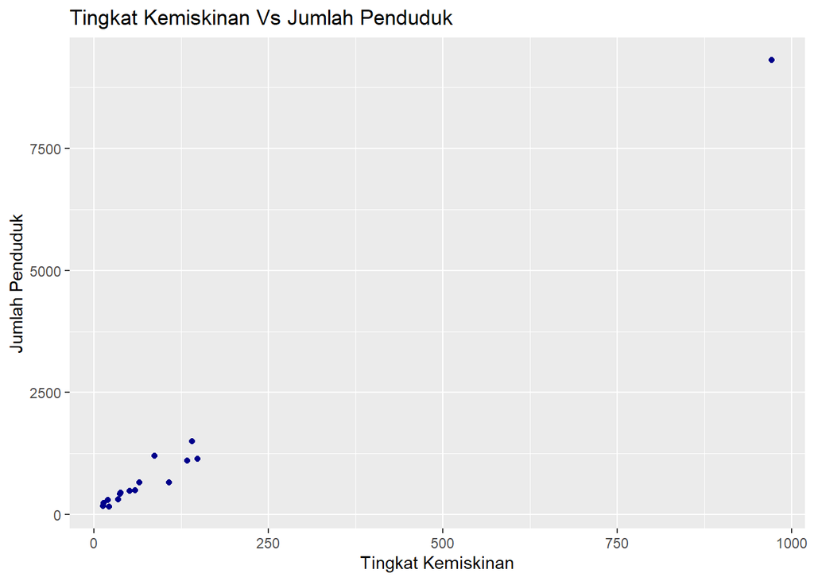

```r
library(ggplot2)

# Scatter plot Jumlah Penduduk vs. Tingkat Pengangguran
ggplot(data = kemiskinan, aes(x = Kemiskinan, y = Jumlah_Penduduk)) +
  geom_point(color = "darkblue") +
  labs(title = "Tingkat Kemiskinan Vs Jumlah Penduduk", x = "Tingkat Kemiskinan", y = "Jumlah Penduduk")
```

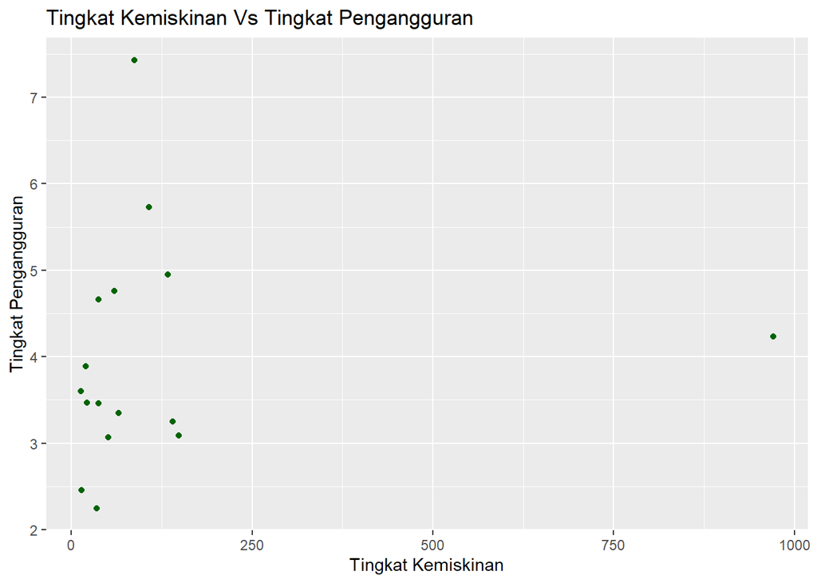

```r
# Scatter plot Jumlah Penduduk vs. IPM
ggplot(data = kemiskinan, aes(x = Kemiskinan, y = Tingkat_Pengganguran)) +
  geom_point(color = "darkgreen") +
  labs(title = "Tingkat Kemiskinan Vs Tingkat Pengangguran", x = "Tingkat Kemiskinan", y = "Tingkat Pengangguran")
```

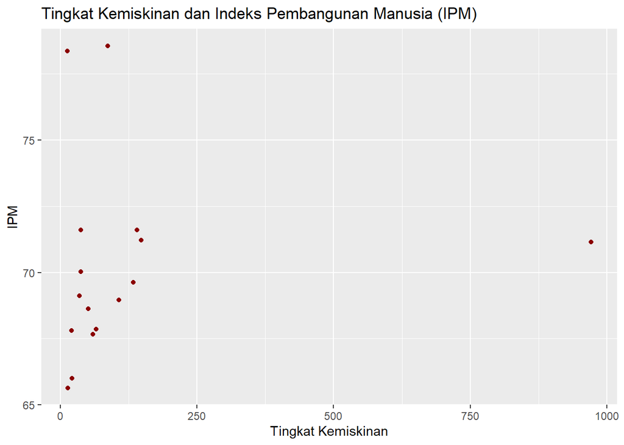

```r
# Scatter plot Tingkat Pengangguran vs. IPM
ggplot(data = kemiskinan, aes(x = Kemiskinan, y = IPM)) +
  geom_point(color = "darkred") +
  labs(title = "Tingkat Kemiskinan dan Indeks Pembangunan Manusia (IPM)", x = "Tingkat Kemiskinan", y = "IPM")
```

## Analisis Regresi Berganda

```r
# Model regresi
anreg <- lm(Kemiskinan ~ Jumlah_Penduduk + Tingkat_Pengganguran + IPM, data = kemiskinan)
anreg
```

```
##
## Call:
## lm(formula = Kemiskinan ~ Jumlah_Penduduk + Tingkat_Pengganguran +
##     IPM, data = kemiskinan)
##
## Coefficients:
##          (Intercept)       Jumlah_Penduduk  Tingkat_Pengganguran
##             141.7504                0.1045                1.3512
##                  IPM
##              -2.0999
```

| Parameter | Nilai |
| --- | --- |
| $\beta_0$ | 141.7504 |
| $\beta_1$ | 0.1045 |
| $\beta_2$ | 1.3512 |
| $\beta_3$ | -2.0999 |

```r
summary(anreg)
```

```
##
## Call:
## lm(formula = Kemiskinan ~ Jumlah_Penduduk + Tingkat_Pengganguran +
##     IPM, data = kemiskinan)
##
## Residuals:
##     Min      1Q  Median      3Q     Max
## -25.397  -9.363  -2.896   4.943  34.157
##
## Coefficients:
##                        Estimate Std. Error t value Pr(>|t|)
## (Intercept)          141.750437  98.088753   1.445    0.174
## Jumlah_Penduduk        0.104533   0.002205  47.416 5.06e-15 ***
## Tingkat_Pengganguran   1.351217   4.214116   0.321    0.754
## IPM                   -2.099909   1.494106  -1.405    0.185
## ---
## Signif. codes:  0 '***' 0.001 '**' 0.01 '*' 0.05 '.' 0.1 ' ' 1
##
## Residual standard error: 18.69 on 12 degrees of freedom
## Multiple R-squared:  0.9948, Adjusted R-squared:  0.9935
## F-statistic: 760.6 on 3 and 12 DF,  p-value: 5.999e-14
```

### **Pendugaan Parameter**

Berdasarkan hasil sumarry diatas, model regresi dari data didapatkan sebagai berikut:

$Y = 141.7504 + 0.1045X_1 + 1.3512X_2 - 2.0999X_3$

### Uji Simultan

Nilai p-value $5.999 * 10^{-14} < 𝛼(0.05)$ maka Ho ditolak. Sehingga dapat disimpulkan bahwa terdapat pengaruh yang signifikan antara varabel prediktor terhadap variabel respons secara simultan.

### Uji Parsial

  Nilai p-value $(0.754) > 𝛼(0.05)$ maka terima Ho. Dapat disimpulkan bahwa tidak terdapat pengaruh yang signifikan antar Tingkat Pengganguran terhadap Kemiskinan.
- **Untuk** $X_3$ **(IPM)**

  Nilai p-value $(0.185) > 𝛼(0.05)$ maka terima Ho. Dapat disimpulkan bahwa tidak terdapat pengaruh yang signifikan antar IPM terhadap Kemiskinan.

## Asumsi Regresi Linier Berganda

### 1. Pendekatan Multikolinearitas

```r
library(car)
vif (anreg)
```

```
##      Jumlah_Penduduk Tingkat_Pengganguran                  IPM
##             1.020771             1.300753             1.303695
```

Karena nilai VIF pada X1, X2, dan X3 berada dibawah 10, maka tidak terjadi multikolinearitas. Artinya, asumsi mutikolinearitas terpenuhi.

### 2. Normalitas Galat

```r
library(tseries)
sisa <- residuals (anreg)
sisa
```

```
##          1          2          3          4          5          6          7
##   2.404826  -7.854415  15.938848  32.431621 -13.168519  34.156980  -1.859068
##          8          9         10         11         12         13         14
##  -8.094927   1.540093  -3.933581 -18.398958 -15.179219  -4.139621 -25.396992
##         15         16
##  12.558921  -1.005988
```

```r
shapiro.test(sisa)
```

```
##
##  Shapiro-Wilk normality test
##
## data:  sisa
## W = 0.92815, p-value = 0.2278
```

**Hipotesis**

Ho : Galat menyebar normal

H1 : Galat tidak menyebar normal berdasarkan uji shapiro wilk

Berdasarkan hasil yang diperoleh didapatkan p-value $(0.2278) > 𝛼(0.05)$ maka Ho diterima. Dapat disimpulkan bahwa galat menyebar normal, dan mengartikan bahwa uji asumsi normalitas terpenuhi.

### 3. Homogenitas Ragam Galat

```r
library("lmtest")
bptest(anreg)
```

```
##
##  studentized Breusch-Pagan test
##
## data:  anreg
## BP = 2.7072, df = 3, p-value = 0.439
```

**Hipotesis**

H0 : Tidak terjadi heteroskdesastisitas

H1 : Terjadi heteroskdesastisitas berdasarkan uji bp-test

Dapat disimpulkan bahwa nilai p-value $(0.439) > 𝛼(0.05)$ maka Ho diterima. Dapat disimpulkan bahwa tidak terjadi heteroskedastisitas artinya asumsi homogenitas ragam galat terpenuhi.

### 4. Non Autokorelasi Galat

```r
dwtest(anreg)
```

```
##
##  Durbin-Watson test
##
## data:  anreg
## DW = 2.1812, p-value = 0.5844
## alternative hypothesis: true autocorrelation is greater than 0
```

**Hipotesis**

H0 : Tidak terjadi autokorelasi

H1 : Terjadi autokorelasi

Berdasarkan uji Durbin Watson, nilai p-value $(0.5844) > 𝛼(0.05)$, maka Ho diterima. Dapat disimpulkan bahwa tidak terjadi kasus autokorelasi pada galat.

### Koefisien Korelasi

Koefisin determinasi didapatkan sebesar $0.9935$ artinya variabel prediktor (Jumlah Penduduk, Tingkat Pengganguran, dan IPM) mempengaruhi variabel respon (Tingkat Kemiskinan) sebesar $99.35\%$, sedangkan sisanya dipengaruhi oleh variabe di luar model.